# MAS2908 - Practical 04 (Solutions)

Clement Lee

Semester 2, 2025/2026

# 1 Introduction

This practical focuses on reading external data and using aesthetics in `ggplot2`. You will learn how to:

- Read CSV files with `readr` and Excel files with `readxl`
- Understand computed variables within `aes()`
- Apply colour scales for discrete and continuous variables (Chapter 4 in notes)
- Use shape, line type, and size aesthetics (Chapter 5 in notes)

The following datasets are used in this practical:

- `mtcars`: Motor Trend car road tests data (1974), available in base R
- `moneydemand`: US money demand data (1879–1974), external — available on Canvas
- `census_ni`: Northern Ireland Census 2021 population data, external — available on Canvas
- `moneydemand_long`: Long-format version of `moneydemand`, derived in this practical from `moneydemand`

# 2 Part A: Reading external data

Before we can visualise data, we often need to read it from external files. Two key packages help with this:

- **`readr`**: For reading CSV and other *flat files* (plain text with values separated by commas, tabs, or other delimiters)
- **`readxl`**: For reading Excel spreadsheets (`.xls` and `.xlsx` files), which are *not* flat files as they can contain multiple sheets, formatting, and formulas

As usual, load these 2 packages together with the usual suspects - `ggplot2` & `dplyr`:

```r
library(readr)
library(readxl)
library(ggplot2)
library(dplyr)
```

As a one-off, if there’s an error saying that there are no such packages, install them using `install.packages("readr")` and so on.

## 2.1 Reading CSV files with `readr`

Download `moneydemand.csv` from Canvas to your working directory, and run the following, where `read_csv()` reads comma-separated value files:

```r
moneydemand <- read_csv("moneydemand.csv")
str(moneydemand) # to have a look at the data
```

This dataset contains US money demand data from 1879 to 1974, with variables:

- `year`: Year of observation
- `logM`: Log of real money stock
- `logYp`: Log of permanent income
- `Rs`: Short-term interest rate
- `Rl`: Long-term interest rate
- `Rm`: Interest rate on money
- `logSpp`: Log of stock prices

### 2.1.1 Common `read_csv()` arguments

| Argument | Purpose |
| --- | --- |
| `file` | Path to the file |
| `col_names` | Use first row as names (`TRUE`) or provide names |
| `col_types` | Specify column types explicitly |
| `skip` | Number of lines to skip before reading |
| `na` | Character vector of strings to treat as NA |

## 2.2 Reading Excel files with `readxl`

The `read_excel()` function reads both `.xls` and `.xlsx` files. Unlike CSV files, Excel spreadsheets can contain multiple sheets and often have header rows that need to be skipped.

As an example, we will read population data from the Northern Ireland Census 2021, available from NISRA (https://www.nisra.gov.uk/publications/census-2021-person-and-household-estimates-data-zones-northern-ireland). We will use this dataset later in this module for geospatial visualisation.

Download the file `census-2021-ms-a14.xlsx`, displayed as “MS-A14 Population density” from the URL above (also available on Canvas), to your working directory, and run the following:

```r
census_ni <- read_excel("census-2021-ms-a14.xlsx",
                        sheet = "SDZ",
                        skip = 5)
str(census_ni) # notice the clunky column names
```

The column names from this file are quite clunky (e.g., `All usual residents`, `Population density (number of usual residents per hectare)`). We can use `dplyr::rename()` to give them cleaner names:

```r
census_ni <- census_ni |>
  rename(
    name = `Geography`,
    code = `Geography code`,
    residents = `All usual residents`,
    area = `Area (hectares)\r\n[note 1, 2]`,
    density = `Population density (number of usual residents per hectare)`,
    profile = `Access census area explorer`
  )
str(census_ni) # much cleaner
```

### 2.2.1 Common `read_excel()` arguments

| Argument | Purpose |
| --- | --- |
| `path` | Path to the file |
| `sheet` | Sheet name or number to read |
| `range` | Cell range to read (e.g., “A1:D10”) |
| `col_names` | Use first row as names or provide names |
| `skip` | Number of rows to skip before reading |

# 3 Part B: Computed variables in aesthetics

Before we explore colours and other aesthetics, let’s consider an important feature of `ggplot2`: you can compute variables directly within `aes()`.

## 3.1 A mathematical relationship

1. Using the `census_ni` data, think about what would happen if you plot `residents` (on the $y$-axis) against the product of `area` and `density` (on the $x$-axis). What shape would you expect the plot to have? Why?

   **Answer**: The plot would be a straight line with slope 1. This is because density is defined as residents/area, so area $\times$ density = area $\times$ (residents/area) = residents. Therefore, we are plotting residents against residents, which gives a straight line $y = x$.
2. Create this plot using `aes(x = area * density, y = residents)`. Verify that the relationship is indeed a straight line.

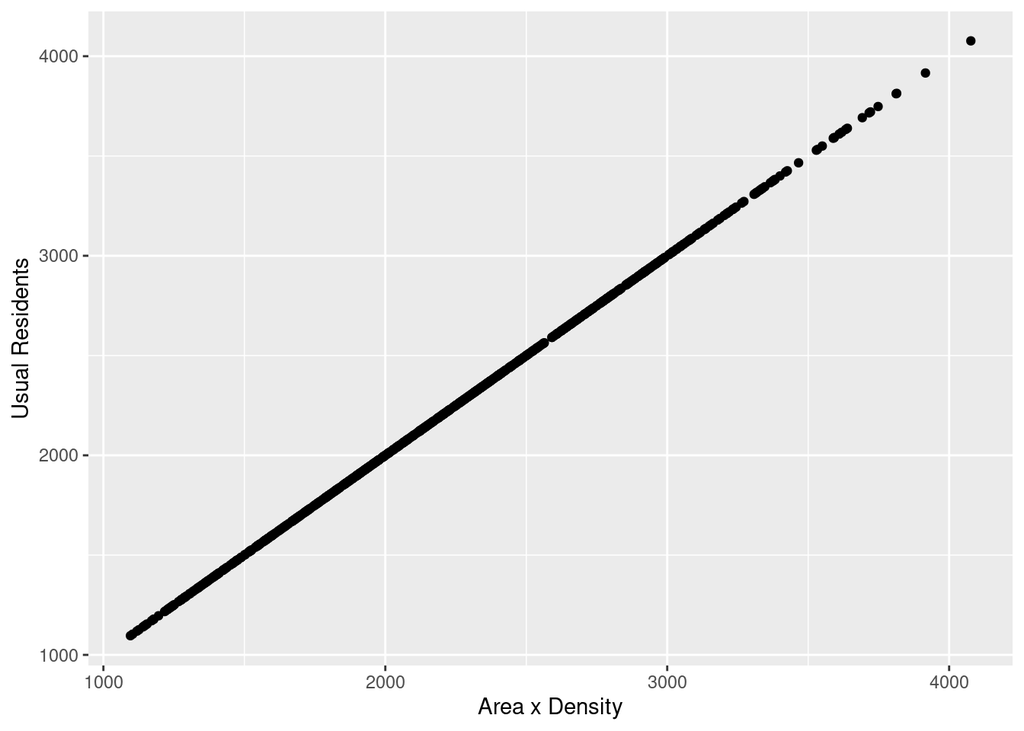

   ```r
   ggplot(census_ni, aes(x = area * density, y = residents)) +
     geom_point() +
     labs(x = "Area x Density", y = "Usual Residents")
   ```

   Note that we computed `area * density` directly within `aes()`. This is a powerful feature that allows you to transform or combine variables without creating new columns in your data frame.

# 4 Part C: Colour aesthetics

Colour is an aesthetic (see Chapter 4 in notes) that maps variables to visual colours. The scale functions control how this mapping works.

## 4.1 Discrete colour scales

3. Using the `mtcars` dataset, create a scatterplot of `mpg` ($y$-axis) vs `wt` ($x$-axis), with points coloured by `cyl` (number of cylinders). Remember to convert `cyl` to a factor using `factor(cyl)`.

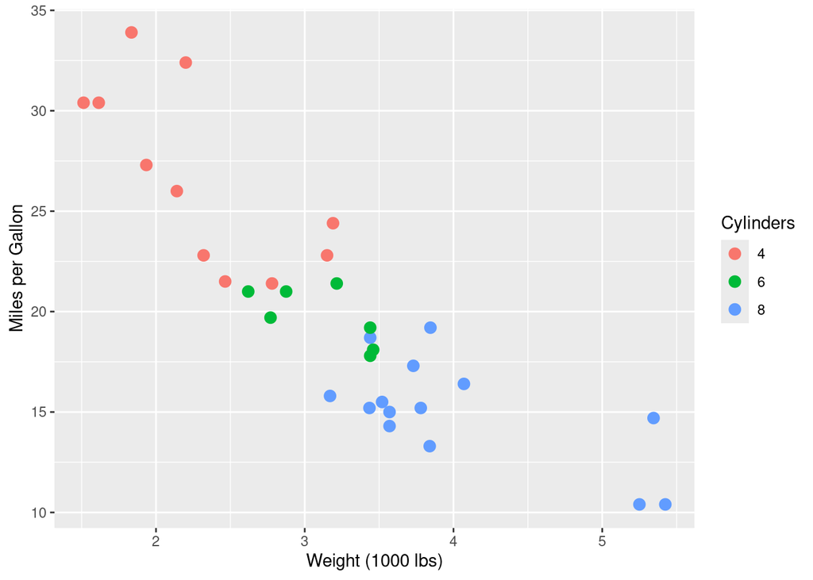

   ```r
   ggplot(mtcars, aes(x = wt, y = mpg, colour = factor(cyl))) +
     geom_point(size = 3) +
     labs(x = "Weight (1000 lbs)", y = "Miles per Gallon", colour = "Cylinders")
   ```

4. Using your plot from Q3, try three different colour scales:
   1. `scale_colour_brewer()` with palette “Set1”
   2. `scale_colour_viridis_d()`
   3. `scale_colour_grey()`

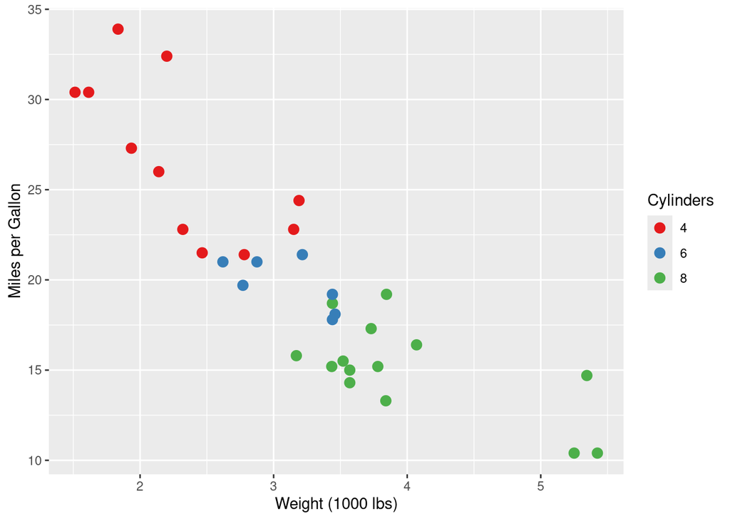

   ```r
   p <- ggplot(mtcars, aes(x = wt, y = mpg, colour = factor(cyl))) +
     geom_point(size = 3) +
     labs(x = "Weight (1000 lbs)", y = "Miles per Gallon", colour = "Cylinders")

   p + scale_colour_brewer(palette = "Set1")
   ```

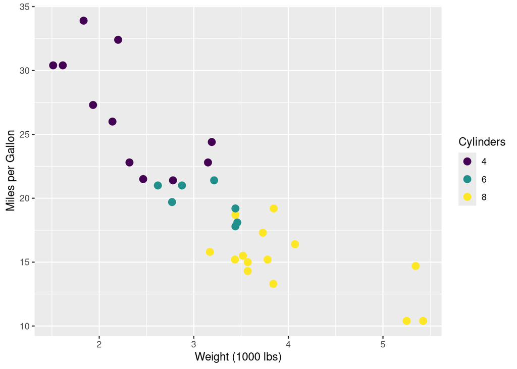

   ```r
   p + scale_colour_viridis_d()
   ```

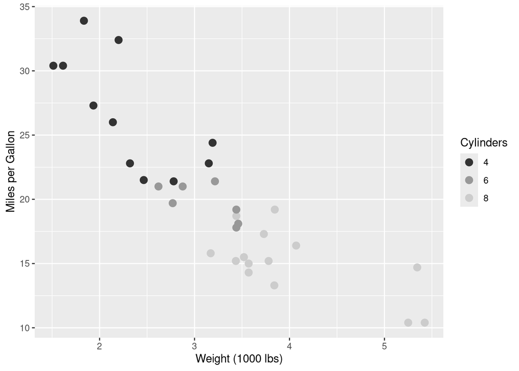

   ```r
   p + scale_colour_grey()
   ```

5. Create a bar chart of `cyl` from `mtcars`, with bars **filled** by `cyl`. Use `scale_fill_viridis_d(option = "E")` for a colour-blind-friendly palette.

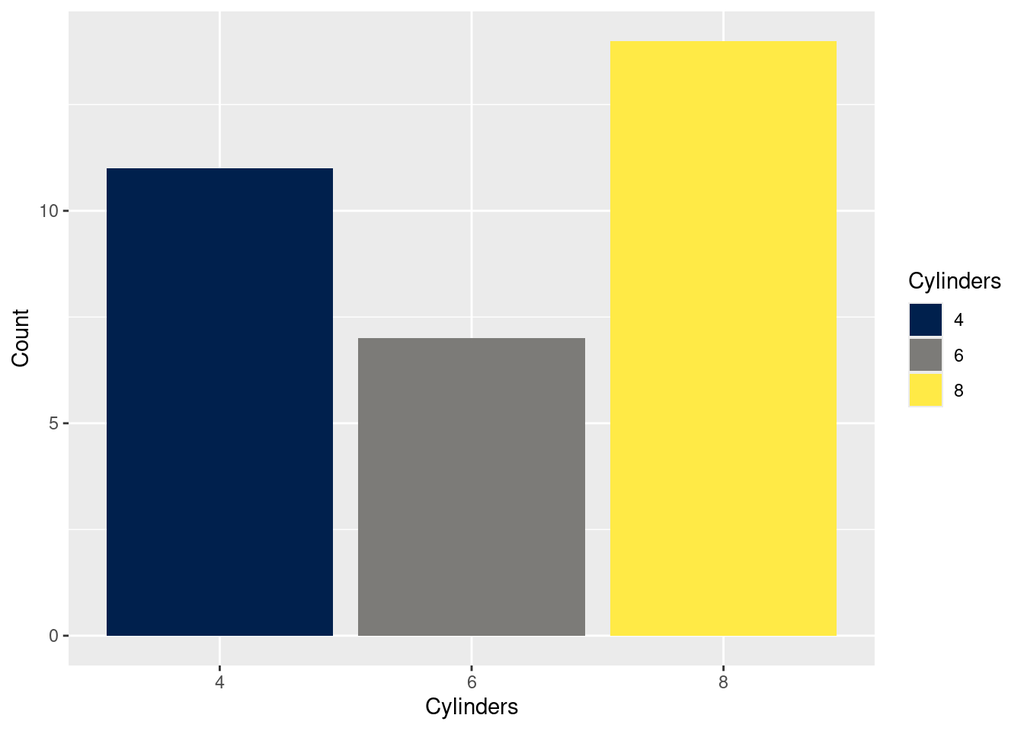

   ```r
   ggplot(mtcars, aes(x = factor(cyl), fill = factor(cyl))) +
     geom_bar() +
     scale_fill_viridis_d(option = "E") +
     labs(x = "Cylinders", y = "Count", fill = "Cylinders")
   ```

   Is this plot truly informative? Explain why or why not, and suggest a fix.

   **Answer**: This plot is not truly informative because the fill colour is redundant with the $x$-axis — both encode the same variable (`cyl`). The colour adds no new information. A better approach would be to fill by a *different* variable, such as `am` (transmission type), which would show how many cars of each cylinder count have automatic vs manual transmission:

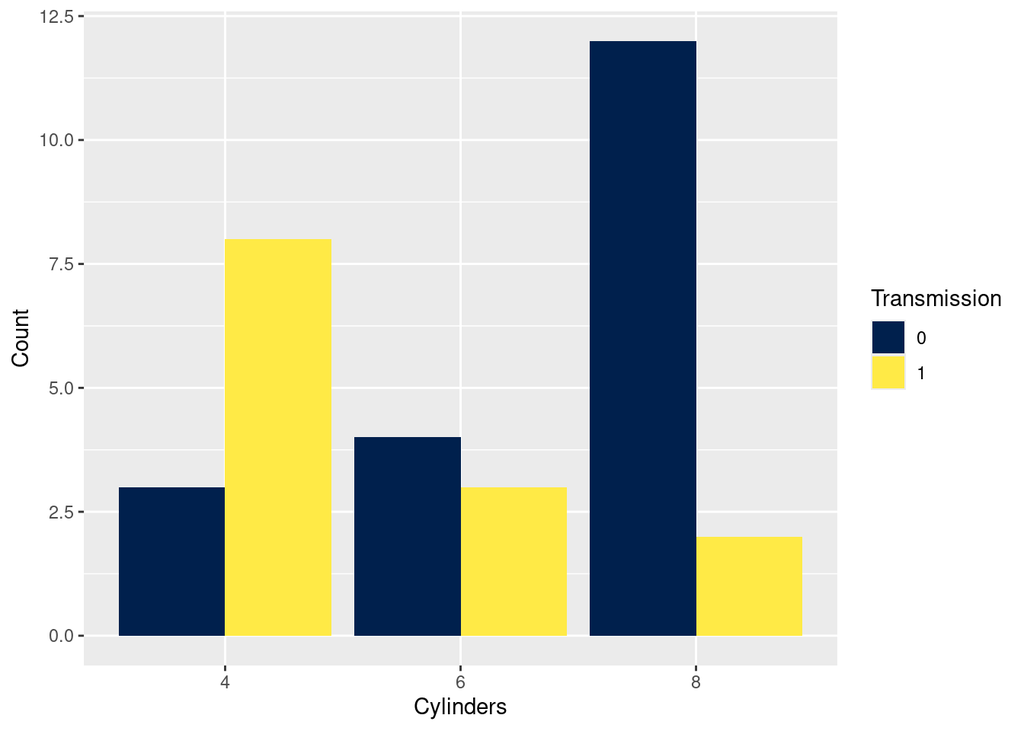

   ```r
   ggplot(mtcars, aes(x = factor(cyl), fill = factor(am))) +
     geom_bar(position = "dodge") +
     scale_fill_viridis_d(option = "E") +
     labs(x = "Cylinders", y = "Count", fill = "Transmission")
   ```

## 4.2 Continuous colour scales

6. Using `moneydemand`, create a scatterplot of `Rl` (long-term rate) vs `Rs` (short-term rate), with colour mapped to `year`. Apply `scale_colour_viridis_c()`.

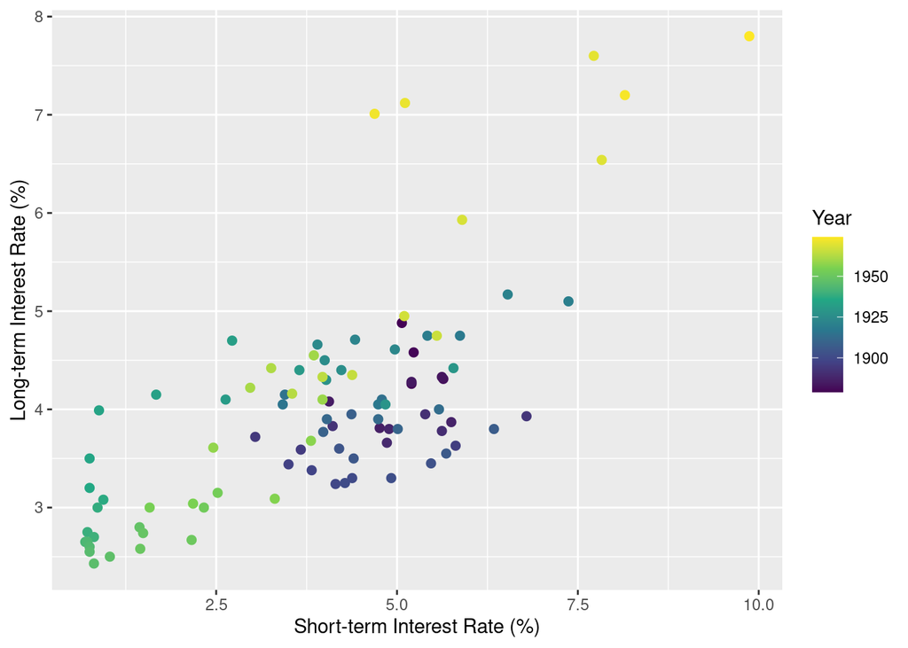

   ```r
   ggplot(moneydemand, aes(x = Rs, y = Rl, colour = year)) +
     geom_point(size = 2) +
     scale_colour_viridis_c() +
     labs(x = "Short-term Interest Rate (%)",
          y = "Long-term Interest Rate (%)",
          colour = "Year")
   ```

7. Create a line plot of `logM` (log money stock) over `year`, with colour mapped to `logYp` (log permanent income). Try both:
   1. `scale_colour_gradient(low = "yellow", high = "red")`
   2. `scale_colour_distiller(palette = "Spectral", direction = 1)`

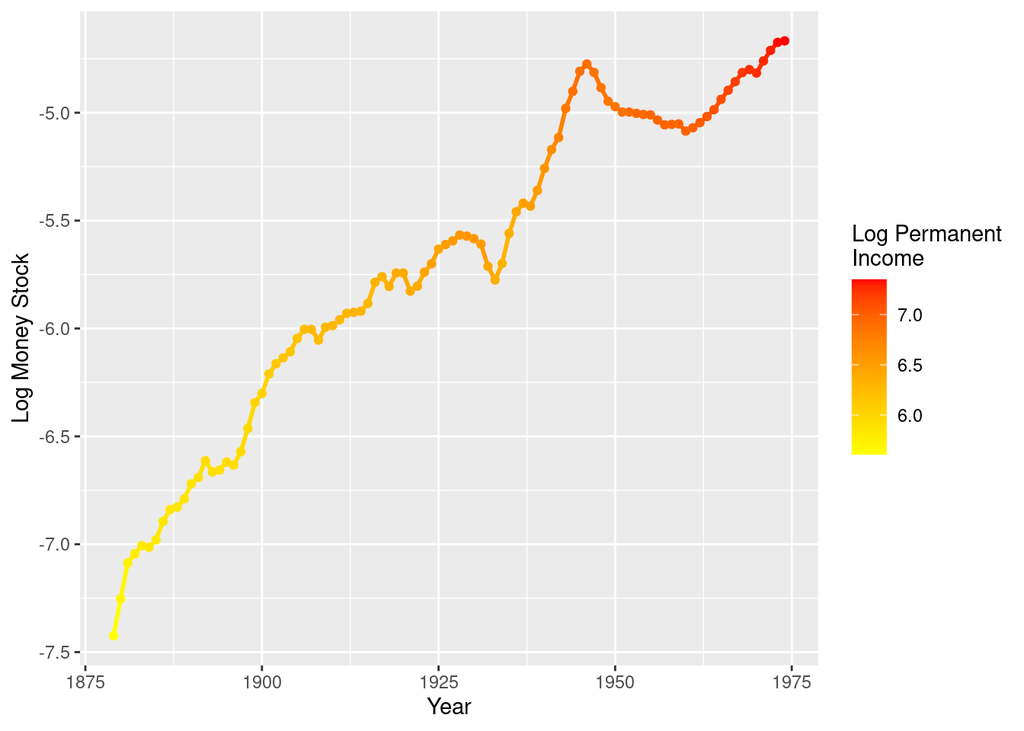

   ```r
   p <- ggplot(moneydemand, aes(x = year, y = logM, colour = logYp)) +
     geom_line(linewidth = 1) +
     geom_point() +
     labs(x = "Year", y = "Log Money Stock",
          colour = "Log Permanent\nIncome")

   p + scale_colour_gradient(low = "yellow", high = "red")
   ```

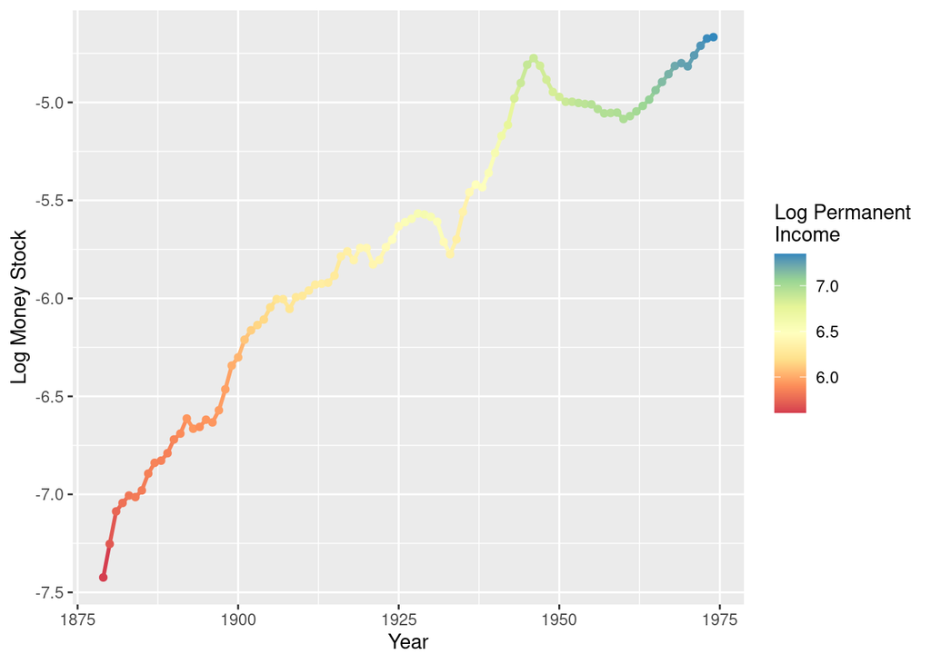

   ```r
   p + scale_colour_distiller(palette = "Spectral", direction = 1)
   ```

## 4.3 Binned colour scales

8. Create the same plot as Q7 (`logM` over `year`, coloured by `logYp`), but use `scale_colour_viridis_b()` instead of a continuous scale. Compare the two versions — which do you find more informative for this data?

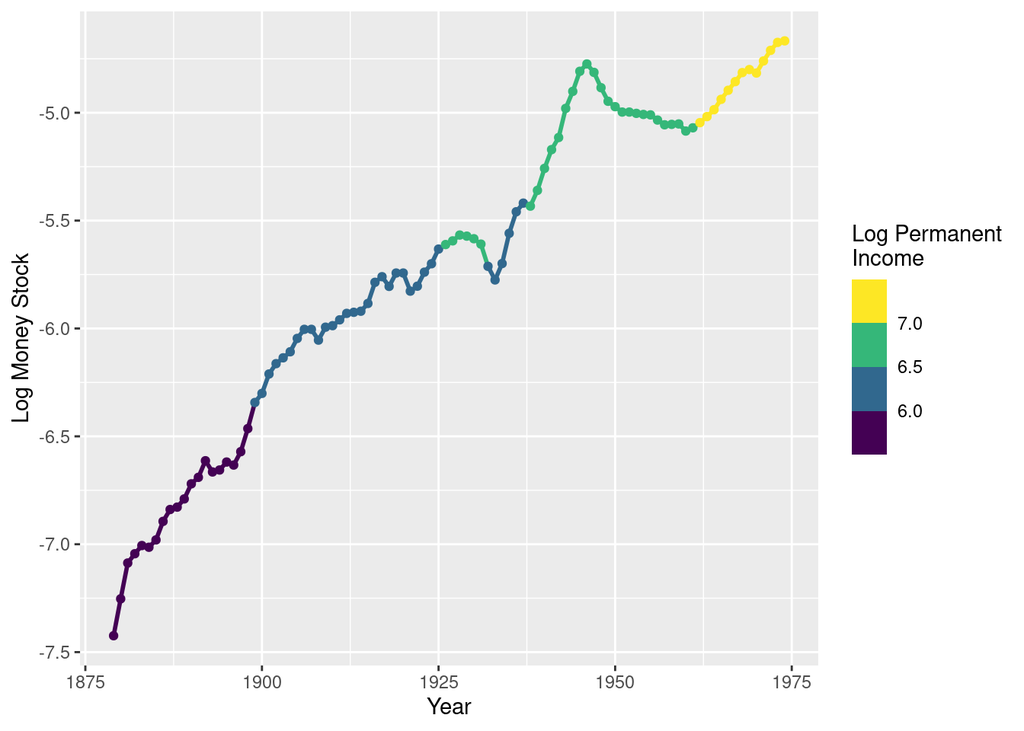

   ```r
   ggplot(moneydemand, aes(x = year, y = logM, colour = logYp)) +
     geom_line(linewidth = 1) +
     geom_point() +
     scale_colour_viridis_b() +
     labs(x = "Year", y = "Log Money Stock",
          colour = "Log Permanent\nIncome")
   ```

# 5 Part D: Other aesthetics

These aesthetics are covered in Chapter 5 in notes.

## 5.1 Shape

10. Using `mtcars`, create a scatterplot of `mpg` vs `wt` with points **shaped** by `gear` (number of gears). Use `scale_shape_manual()` to set shapes 16 (filled circle), 17 (filled triangle), and 15 (filled square) for the three gear values.

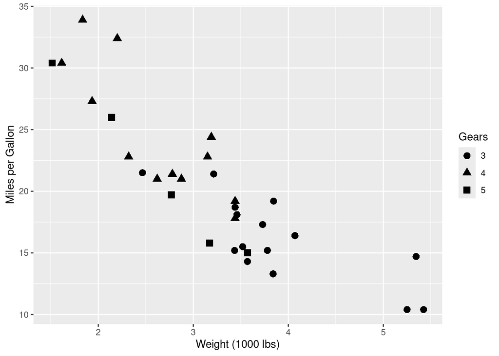

    ```r
    ggplot(mtcars, aes(x = wt, y = mpg, shape = factor(gear))) +
      geom_point(size = 3) +
      scale_shape_manual(values = c("3" = 16, "4" = 17, "5" = 15)) +
      labs(x = "Weight (1000 lbs)", y = "Miles per Gallon", shape = "Gears")
    ```

11. Create the same plot as Q10, but add **both** shape and colour to represent the number of gears. This is called “redundant encoding”. Apply `scale_colour_brewer(palette = "Set1")` for the colour.

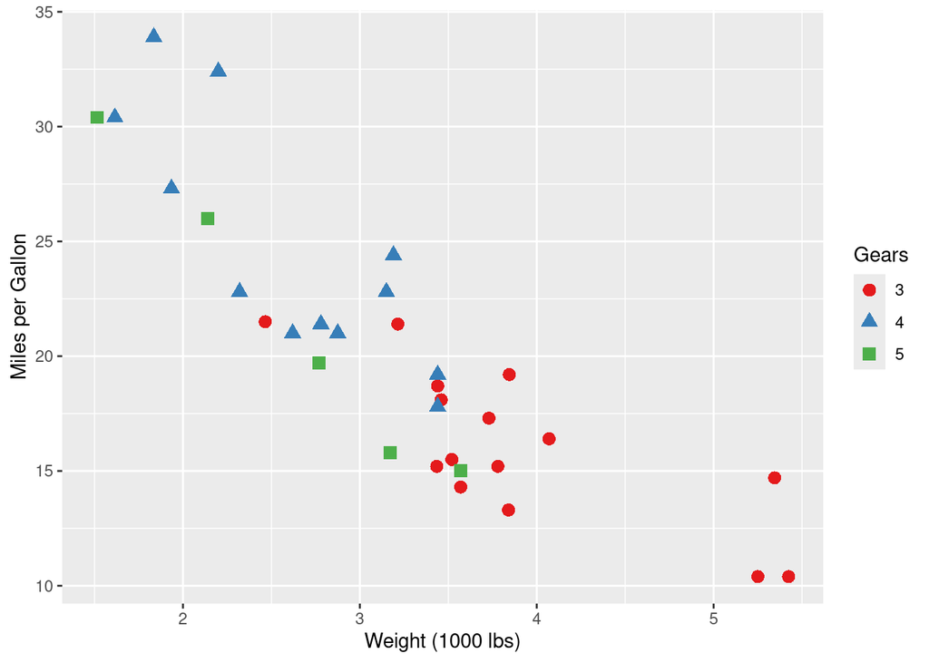

    ```r
    ggplot(mtcars, aes(x = wt, y = mpg, shape = factor(gear),
                       colour = factor(gear))) +
      geom_point(size = 3) +
      scale_shape_manual(values = c("3" = 16, "4" = 17, "5" = 15)) +
      scale_colour_brewer(palette = "Set1") +
      labs(x = "Weight (1000 lbs)", y = "Miles per Gallon",
           shape = "Gears", colour = "Gears")
    ```

## 5.2 Size

12. Using `moneydemand`, create a scatterplot of `Rl` vs `Rs` with point **size** mapped to `logM`. Use `scale_size_continuous(range = c(1, 8))` and set `alpha = 0.6` for transparency.

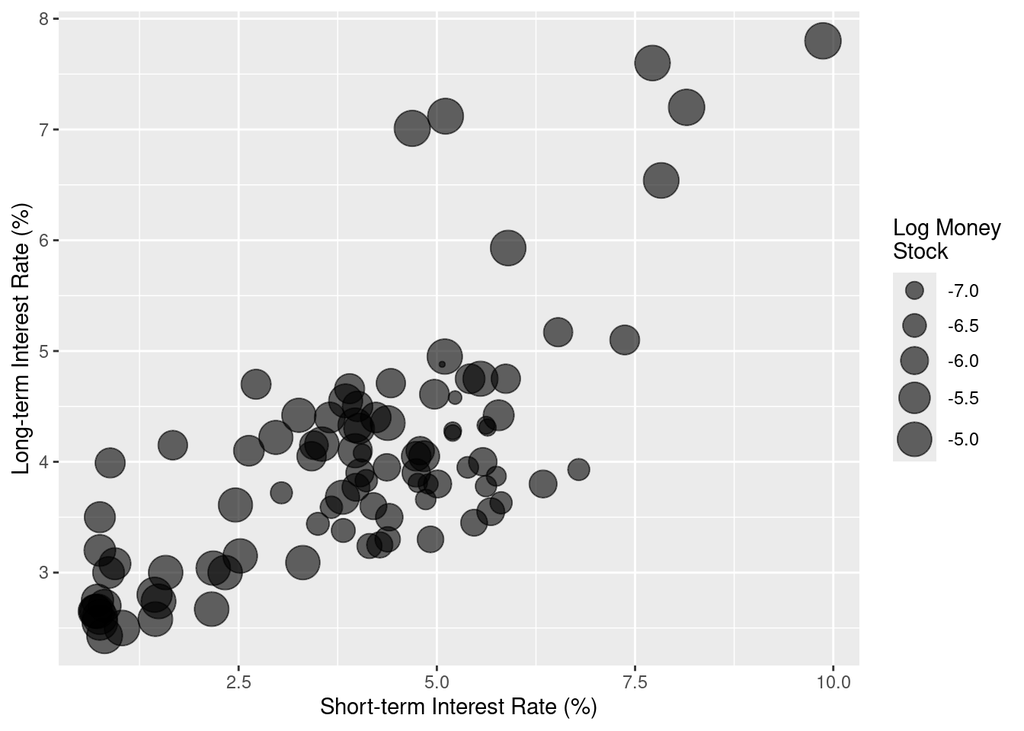

    ```r
    ggplot(moneydemand, aes(x = Rs, y = Rl, size = logM)) +
      geom_point(alpha = 0.6) +
      scale_size_continuous(range = c(1, 8)) +
      labs(x = "Short-term Interest Rate (%)",
           y = "Long-term Interest Rate (%)",
           size = "Log Money\nStock")
    ```

13. Create a scatterplot of `mpg` vs `wt` from `mtcars` that uses **three** aesthetics: colour for `cyl`, shape for `gear`, and size for `hp`. Comment on whether this plot is easy to interpret.

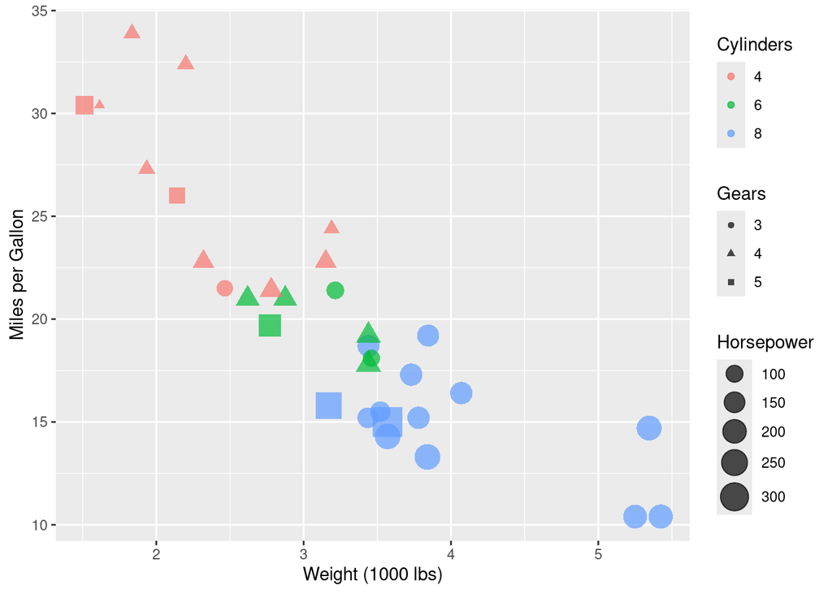

    ```r
    ggplot(mtcars, aes(x = wt, y = mpg, colour = factor(cyl),
                       shape = factor(gear), size = hp)) +
      geom_point(alpha = 0.7) +
      scale_size_continuous(range = c(2, 8)) +
      labs(x = "Weight (1000 lbs)", y = "Miles per Gallon",
           colour = "Cylinders", shape = "Gears", size = "Horsepower")
    ```

    This plot is getting close to the limit of perception and interpretation because it encodes quite a few variables at once. While it’s technically possible, the cognitive load is high. Generally, limit plots to 2–3 encoded variables for clarity.

## 5.3 Line type

In the notes (Chapter 5), we used `economics` and `economics_long` — both built into `ggplot2` — as examples of the same data in wide and long format respectively. Here, we create a similar long-format dataset manually from `moneydemand`.

To compare multiple variables on the same plot using different line types, we sometimes need to reshape the data from “wide” format (one column per variable) to “long” format (one column for the variable name, one for the value). While reshaping data is out of scope for this module, the `tidyr` package provides useful functions like `pivot_longer()` for this purpose.

For now, we will create the reshaped data manually:

```r
# Create long-format data manually
moneydemand_long <- data.frame(
  year = rep(moneydemand$year, 2),
  rate_type = rep(c("Rs", "Rl"), each = nrow(moneydemand)),
  rate = c(moneydemand$Rs, moneydemand$Rl)
)
head(moneydemand_long)
```

```
##   year rate_type  rate
## 1 1879        Rs 5.067
## 2 1880        Rs 5.230
## 3 1881        Rs 5.200
## 4 1882        Rs 5.640
## 5 1883        Rs 5.620
## 6 1884        Rs 5.200
```

14. Using `moneydemand_long`, create a plot with two lines: one for `Rs` and one for `Rl`, both plotted against `year`. Map `linetype` to `rate_type`.

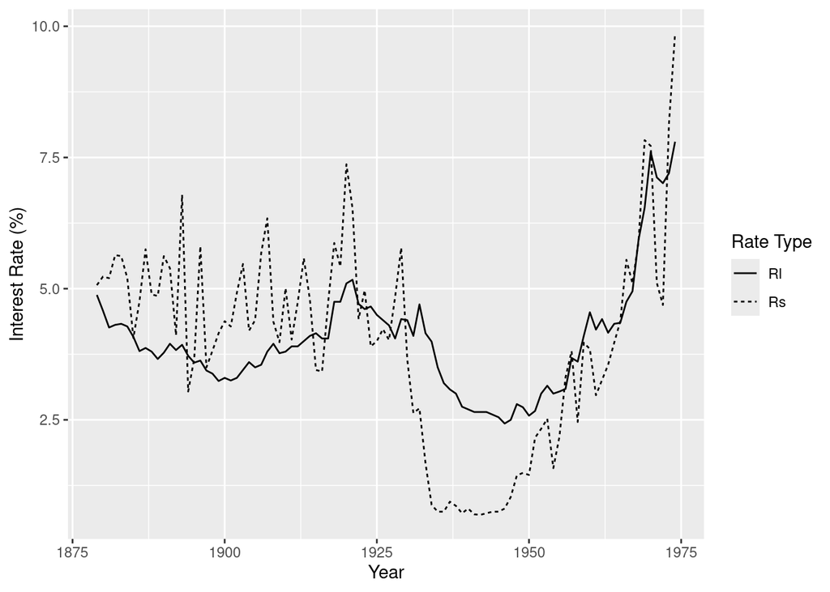

    ```r
    ggplot(moneydemand_long, aes(x = year, y = rate, linetype = rate_type)) +
      geom_line() +
      labs(x = "Year", y = "Interest Rate (%)", linetype = "Rate Type")
    ```

15. Enhance the plot from Q14 by also mapping `colour` to `rate_type`, creating redundant encoding. Use `scale_colour_viridis_d()`.

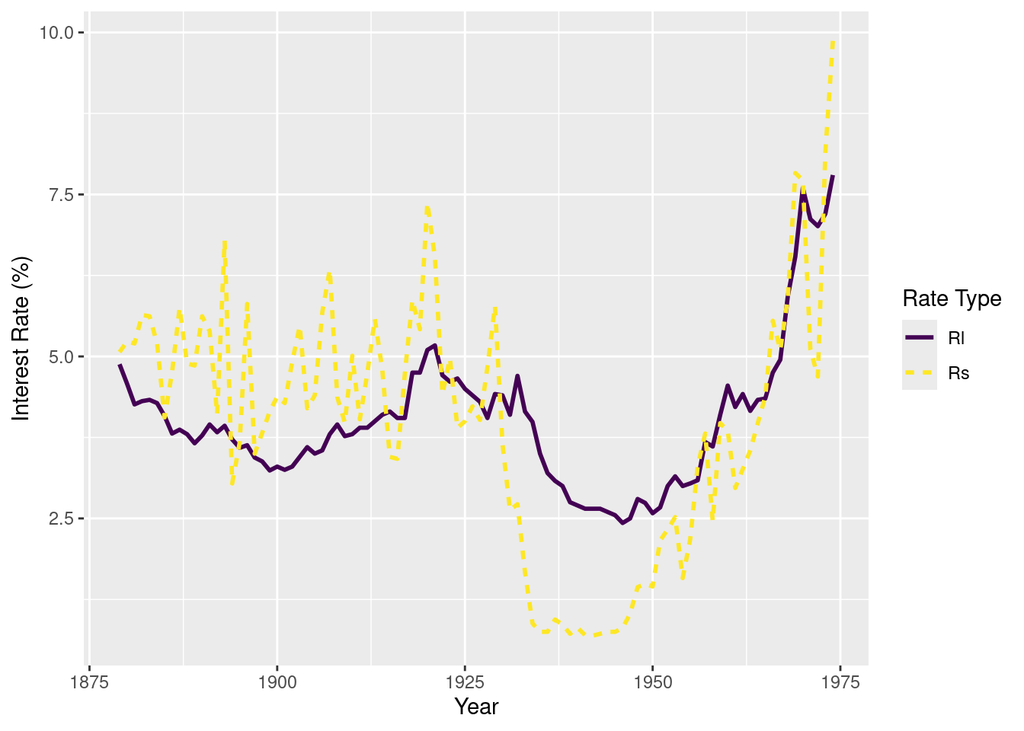

    ```r
    ggplot(moneydemand_long, aes(x = year, y = rate, linetype = rate_type,
                                  colour = rate_type)) +
      geom_line(linewidth = 1) +
      scale_colour_viridis_d() +
      labs(x = "Year", y = "Interest Rate (%)",
           linetype = "Rate Type", colour = "Rate Type")
    ```

# 6 Summary

**Reading data:**

- `read_csv()` from `readr`: for CSV and other flat files
- `read_excel()` from `readxl`: for Excel spreadsheets (not flat)
- Common arguments: `skip`, `col_names`, `col_types`, `sheet`, `range`
- Use `dplyr::rename()` to fix clunky column names

**Computed variables:**

- You can compute expressions directly within `aes()`, e.g., `aes(x = a * b)`
- `factor(cyl)` used throughout this practical is another example: it converts the numeric `cyl` to a categorical factor, directly inside `aes()`
- Understanding mathematical relationships helps predict plot shapes

**Colour aesthetics:**

- Use `colour` for points/lines/outlines; use `fill` for bar/box interiors
- Match scale type to variable type:
  - Discrete (categorical): `scale_*_viridis_d()`, `scale_*_brewer()`
  - Continuous: `scale_*_viridis_c()`, `scale_*_distiller()`, `scale_*_gradient()`
  - Binned continuous: `scale_*_viridis_b()`, `scale_*_fermenter()`
- Using the wrong scale type causes errors

**Other aesthetics:**

- Shape: `scale_shape_manual()` to specify exact shapes (only for categorical)
- Line type: for distinguishing lines, especially in black-and-white
- Size: `scale_size_continuous(range = c(min, max))` to control size range
- Redundant encoding (colour + shape) helps for accessibility but uses up aesthetics
- Avoid encoding too many variables at once — 2–3 is usually the limit